# 1. Imports

## 1.1 Packages

```python
import os
import numpy as np
import pandas as pd
import pickle
import sys

import shap
import plotly.express as px
```

```python
# Load custom functions
sys.path.append("../src/")
from prepare_data import get_holidays
from feature_engineering import extract_date_features, add_lockdown_periods, add_holidays_period,\
    get_split_train_val_cv
from train_model import create_pool, unsold_rate, sold_out_rate, compute_shap
from analyze_model import get_soldout_rows, get_unsold_rows
```

## 1.2 Options

```python
%load_ext autoreload
%autoreload 2
```

```
The autoreload extension is already loaded. To reload it, use:
  %reload_ext autoreload
```

```python
# Define some parameters

path_data = "../data/processed"
path_model = "../models/model_final.json"

feat_date = "Date"
```

## 1.3 Datasets

```python
# Load the train and test sets and their targets

df_train = pd.read_pickle(os.path.join(path_data, "train.pkl"))
y_train = pd.read_csv(os.path.join(path_data, "target_train.csv"), index_col=0)

df_test = pd.read_pickle(os.path.join(path_data, "test.pkl"))
y_test = pd.read_csv(os.path.join(path_data, "target_test.csv"), index_col=0)
```

# 2. Prepare data

## 2.1 Feature engineering

To prepare data, the following feature engineering is done:

1. Extract info from date: year, month, day, day of the week and if its weekend or not
2. Add an indicator of the lockdown period: if there was a lockdown, and which one (first, second or thrid one)
3. Add holidays period for Zone A in France
4. Add holidays period for Zone B in France
5. Add holidays period for Zone C in France

(Having some geographical information could let us add just the right holidays period depending on the zone)

1. Drop columns Date and Fourni which will not be used in the model

```python
df_date_train = df_train[feat_date]
df_date_test = df_test[feat_date]
```

```python
df_train = df_train.pipe(extract_date_features, feat_date=feat_date)\
    .pipe(add_lockdown_periods, feat_date=feat_date)\
    .pipe(add_holidays_period, feat_date=feat_date, zone="Zone A")\
    .pipe(add_holidays_period, feat_date=feat_date, zone="Zone B")\
    .pipe(add_holidays_period, feat_date=feat_date, zone="Zone C")

df_test = df_test.pipe(extract_date_features, feat_date=feat_date)\
    .pipe(add_lockdown_periods, feat_date=feat_date)\
    .pipe(add_holidays_period, feat_date=feat_date, zone="Zone A")\
    .pipe(add_holidays_period, feat_date=feat_date, zone="Zone B")\
    .pipe(add_holidays_period, feat_date=feat_date, zone="Zone C")
```

```python
df_train
```

|  | Date | Fourni | id | sma_1_ventes_lag14 | sma_2_ventes_lag14 | sma_3_ventes_lag14 | sma_4_ventes_lag14 | sma_5_ventes_lag14 | sma_6_ventes_lag14 | sma_7_ventes_lag14 | ... | sma_34_ventes_lag14 | Date_year | Date_month | Date_day | Date_weekday | Date_weekend | lockdown | Description_ZoneA | Description_ZoneB | Description_ZoneC |
| --- | --- | --- | --- | --- | --- | --- | --- | --- | --- | --- | --- | --- | --- | --- | --- | --- | --- | --- | --- | --- | --- |
| 63 | 2020-01-02 | 8.0 | 6199345349144345845 | NaN | NaN | NaN | NaN | NaN | NaN | NaN | ... | NaN | 2020 | 1 | 2 | 3 | 0 | 0 | Vacances de Noël | Vacances de Noël | Vacances de Noël |
| 72 | 2020-01-02 | 7.0 | -876129535061941331 | NaN | NaN | NaN | NaN | NaN | NaN | NaN | ... | NaN | 2020 | 1 | 2 | 3 | 0 | 0 | Vacances de Noël | Vacances de Noël | Vacances de Noël |
| 1 | 2020-01-02 | 8.0 | -8929187383922749181 | NaN | NaN | NaN | NaN | NaN | NaN | NaN | ... | NaN | 2020 | 1 | 2 | 3 | 0 | 0 | Vacances de Noël | Vacances de Noël | Vacances de Noël |
| 24 | 2020-01-02 | 2.0 | 8464427600310081793 | NaN | NaN | NaN | NaN | NaN | NaN | NaN | ... | NaN | 2020 | 1 | 2 | 3 | 0 | 0 | Vacances de Noël | Vacances de Noël | Vacances de Noël |
| 2 | 2020-01-02 | 14.0 | 5557283775796994165 | NaN | NaN | NaN | NaN | NaN | NaN | NaN | ... | NaN | 2020 | 1 | 2 | 3 | 0 | 0 | Vacances de Noël | Vacances de Noël | Vacances de Noël |
| ... | ... | ... | ... | ... | ... | ... | ... | ... | ... | ... | ... | ... | ... | ... | ... | ... | ... | ... | ... | ... | ... |
| 82388 | 2023-04-02 | 20.0 | -7098573545404969117 | 18.0 | 16.0 | 13.333333 | 12.25 | 11.6 | 11.333333 | 11.714286 | ... | 11.764706 | 2023 | 4 | 2 | 6 | 1 | 0 | None | None | None |
| 82389 | 2023-04-02 | 10.0 | 2942031581314612067 | 8.0 | 6.5 | 5.666667 | 4.75 | 4.6 | 4.666667 | 4.571429 | ... | 3.941176 | 2023 | 4 | 2 | 6 | 1 | 0 | None | None | None |
| 82365 | 2023-04-02 | 30.0 | 6421054819254012950 | 45.0 | 31.0 | 26.333333 | 20.50 | 19.8 | 20.166667 | 21.285714 | ... | 21.941176 | 2023 | 4 | 2 | 6 | 1 | 0 | None | None | None |
| 82384 | 2023-04-02 | 7.0 | -3559041973219712811 | 3.0 | 2.5 | 1.666667 | 1.25 | 1.0 | 0.833333 | 0.714286 | ... | 1.235294 | 2023 | 4 | 2 | 6 | 1 | 0 | None | None | None |
| 82356 | 2023-04-02 | 30.0 | 6858783929733742556 | 24.0 | 30.5 | 24.666667 | 21.25 | 20.8 | 19.333333 | 19.142857 | ... | 23.411765 | 2023 | 4 | 2 | 6 | 1 | 0 | None | None | None |

82391 rows × 23 columns

```python
df_test
```

|  | Date | Fourni | id | sma_1_ventes_lag14 | sma_2_ventes_lag14 | sma_3_ventes_lag14 | sma_4_ventes_lag14 | sma_5_ventes_lag14 | sma_6_ventes_lag14 | sma_7_ventes_lag14 | ... | sma_34_ventes_lag14 | Date_year | Date_month | Date_day | Date_weekday | Date_weekend | lockdown | Description_ZoneA | Description_ZoneB | Description_ZoneC |
| --- | --- | --- | --- | --- | --- | --- | --- | --- | --- | --- | --- | --- | --- | --- | --- | --- | --- | --- | --- | --- | --- |
| 82435 | 2023-04-03 | 20.0 | -7760658437998414862 | 11.0 | 11.5 | 16.666667 | 15.75 | 15.2 | 14.666667 | 14.571429 | ... | 15.264706 | 2023 | 4 | 3 | 0 | 0 | 0 | None | None | None |
| 82391 | 2023-04-03 | 15.0 | 5557283775796994165 | 8.0 | 8.5 | 12.333333 | 10.75 | 10.4 | 10.500000 | 10.000000 | ... | 10.676471 | 2023 | 4 | 3 | 0 | 0 | 0 | None | None | None |
| 82392 | 2023-04-03 | 2.0 | 5169110700785508591 | 1.0 | 1.0 | 1.666667 | 1.50 | 1.2 | 1.000000 | 0.857143 | ... | 0.264706 | 2023 | 4 | 3 | 0 | 0 | 0 | None | None | None |
| 82393 | 2023-04-03 | 1.0 | 3502243892823802503 | 1.0 | 0.5 | 1.000000 | 1.00 | 1.0 | 0.833333 | 1.142857 | ... | 1.000000 | 2023 | 4 | 3 | 0 | 0 | 0 | None | None | None |
| 82394 | 2023-04-03 | 5.0 | -439429952026179579 | 3.0 | 2.0 | 2.333333 | 2.75 | 2.4 | 2.666667 | 2.571429 | ... | 2.352941 | 2023 | 4 | 3 | 0 | 0 | 0 | None | None | None |
| ... | ... | ... | ... | ... | ... | ... | ... | ... | ... | ... | ... | ... | ... | ... | ... | ... | ... | ... | ... | ... | ... |
| 83346 | 2023-04-17 | 9.0 | 7102716272888503077 | 4.0 | 6.5 | 6.666667 | 6.50 | 7.2 | 6.833333 | 6.285714 | ... | 6.882353 | 2023 | 4 | 17 | 0 | 0 | 0 | Vacances de Printemps | Vacances de Printemps | None |
| 83335 | 2023-04-17 | 15.0 | 4996385419920977204 | 10.0 | 11.5 | 14.000000 | 12.50 | 11.8 | 11.666667 | 11.285714 | ... | 11.941176 | 2023 | 4 | 17 | 0 | 0 | 0 | Vacances de Printemps | Vacances de Printemps | None |
| 83348 | 2023-04-17 | 15.0 | -7098573545404969117 | 14.0 | 12.5 | 13.666667 | 12.00 | 11.0 | 11.000000 | 11.000000 | ... | 10.735294 | 2023 | 4 | 17 | 0 | 0 | 0 | Vacances de Printemps | Vacances de Printemps | None |
| 83322 | 2023-04-17 | 10.0 | -6620843443548962411 | 12.0 | 9.0 | 10.666667 | 9.00 | 8.2 | 7.166667 | 7.857143 | ... | 7.588235 | 2023 | 4 | 17 | 0 | 0 | 0 | Vacances de Printemps | Vacances de Printemps | None |
| 83350 | 2023-04-17 | 10.0 | 1129067540243158717 | 0.0 | 0.0 | 0.000000 | 1.00 | 2.0 | 3.333333 | 3.428571 | ... | 5.941176 | 2023 | 4 | 17 | 0 | 0 | 0 | Vacances de Printemps | Vacances de Printemps | None |

960 rows × 23 columns

# 3. Analyze model

```python
# Load model
with open(path_model, "rb") as fp:
    data_model = pickle.load(fp)

model = data_model["model"]
feat = data_model["features"]
feat_cat = data_model["features_cat"]
```

## 3.1 SHAP values

Check the SHAP values to see the importance of the features

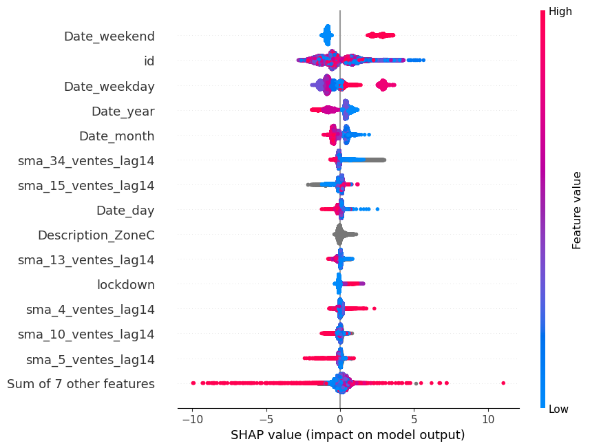

```python
shap_values = compute_shap(model, df_train[feat])
shap.initjs()
shap.plots.beeswarm(shap_values, max_display=15, show=True)
```

The features about the days of the week are the most important:

- Weekday with the high values, corresponding to the end of the week predicting a higher value
- Weekend with a higher prediction during the weekend
- Id is important as the number of newspapers sold depends on the point of sale
- Month has an influence as the beginning of the year means more sales
- Year. The trend of newspapers' sales is understood by the model

## 3.2 Analyze metrics

```python
pool_train = create_pool(df_train[feat], y_train, feat_cat)
pool_test = create_pool(df_test[feat], y_test, feat_cat)

pred_train = np.round(model.predict(pool_train), 0)
pred_test = np.round(model.predict(pool_test), 0)
```

```python
# Check the solution provided as a reference
soldout_train = sold_out_rate(df_train["Fourni"].values, y_train.values)
soldout_test = sold_out_rate(df_test["Fourni"].values, y_test.values)
unsold_train = unsold_rate(df_train["Fourni"].values, y_train.values)
unsold_test = unsold_rate(df_test["Fourni"].values, y_test.values)

print("The sold out rates are:", soldout_train, "for the train set and", soldout_test, "for the test set")
print("The unsold rates are:", unsold_train, "for the train set and", unsold_test, "for the test set")
```

```
The sold out rates are: 3011.8005971526018 for the train set and 41.005208333333336 for the test set
The unsold rates are: 0.32887661746967434 for the train set and 0.20328140287499058 for the test set
```

```python
soldout_train = sold_out_rate(pred_train, y_train.values)
soldout_test = sold_out_rate(pred_test, y_test.values)
unsold_train = unsold_rate(pred_train, y_train.values)
unsold_test = unsold_rate(pred_test, y_test.values)

print("The sold out rates are:", soldout_train, "for the train set and", soldout_test, "for the test set")
print("The unsold rates are:", unsold_train, "for the train set and", unsold_test, "for the test set")
```

```
The sold out rates are: 1845.060115789346 for the train set and 35.197916666666664 for the test set
The unsold rates are: 0.27838829101488444 for the train set and 0.14787088464944056 for the test set
```

The sold out rate is smaller for our predictions but the unsold rates are also a bit smaller. Depending on the right balance between the two metrics we want, we can modify a bit our model

### 3.2.1 Sold out

```python
# Get the sold out info
df_train_soldout = get_soldout_rows(df_train, pred_train, y_train.values)
df_train_soldout["missing_papers"] = df_train_soldout['ventes'] - df_train_soldout['fourni']
df_train_soldout["missing_papers_perc"] = df_train_soldout["missing_papers"] / df_train_soldout['ventes'] * 100
df_train_soldout
```

|  | Date | Fourni | id | sma_1_ventes_lag14 | sma_2_ventes_lag14 | sma_3_ventes_lag14 | sma_4_ventes_lag14 | sma_5_ventes_lag14 | sma_6_ventes_lag14 | sma_7_ventes_lag14 | ... | Date_weekday | Date_weekend | lockdown | Description_ZoneA | Description_ZoneB | Description_ZoneC | ventes | fourni | missing_papers | missing_papers_perc |
| --- | --- | --- | --- | --- | --- | --- | --- | --- | --- | --- | --- | --- | --- | --- | --- | --- | --- | --- | --- | --- | --- |
| 12 | 2020-01-02 | 5.0 | -5497288280538946297 | NaN | NaN | NaN | NaN | NaN | NaN | NaN | ... | 3 | 0 | 0 | Vacances de Noël | Vacances de Noël | Vacances de Noël | 18.0 | 13.0 | 5.0 | 27.777778 |
| 19 | 2020-01-02 | 18.0 | -4877794949675591399 | NaN | NaN | NaN | NaN | NaN | NaN | NaN | ... | 3 | 0 | 0 | Vacances de Noël | Vacances de Noël | Vacances de Noël | 87.0 | 12.0 | 75.0 | 86.206897 |
| 20 | 2020-01-02 | 12.0 | -8817594176277759455 | NaN | NaN | NaN | NaN | NaN | NaN | NaN | ... | 3 | 0 | 0 | Vacances de Noël | Vacances de Noël | Vacances de Noël | 31.0 | 10.0 | 21.0 | 67.741935 |
| 36 | 2020-01-02 | 6.0 | 8038688347558291976 | NaN | NaN | NaN | NaN | NaN | NaN | NaN | ... | 3 | 0 | 0 | Vacances de Noël | Vacances de Noël | Vacances de Noël | 12.0 | 12.0 | 0.0 | 0.000000 |
| 25 | 2020-01-02 | 18.0 | 9170532674782479733 | NaN | NaN | NaN | NaN | NaN | NaN | NaN | ... | 3 | 0 | 0 | Vacances de Noël | Vacances de Noël | Vacances de Noël | 30.0 | 14.0 | 16.0 | 53.333333 |
| ... | ... | ... | ... | ... | ... | ... | ... | ... | ... | ... | ... | ... | ... | ... | ... | ... | ... | ... | ... | ... | ... |
| 82380 | 2023-04-02 | 5.0 | 9099068452793169692 | 4.0 | 5.0 | 4.000000 | 3.25 | 2.8 | 2.500000 | 2.285714 | ... | 6 | 1 | 0 | None | None | None | 17.0 | 16.0 | 1.0 | 5.882353 |
| 82386 | 2023-04-02 | 11.0 | 891824192628202105 | 6.0 | 8.5 | 6.000000 | 4.75 | 4.0 | 3.500000 | 3.285714 | ... | 6 | 1 | 0 | None | None | None | 30.0 | 19.0 | 11.0 | 36.666667 |
| 82365 | 2023-04-02 | 30.0 | 6421054819254012950 | 45.0 | 31.0 | 26.333333 | 20.50 | 19.8 | 20.166667 | 21.285714 | ... | 6 | 1 | 0 | None | None | None | 17.0 | 15.0 | 2.0 | 11.764706 |
| 82384 | 2023-04-02 | 7.0 | -3559041973219712811 | 3.0 | 2.5 | 1.666667 | 1.25 | 1.0 | 0.833333 | 0.714286 | ... | 6 | 1 | 0 | None | None | None | 32.0 | 20.0 | 12.0 | 37.500000 |
| 82356 | 2023-04-02 | 30.0 | 6858783929733742556 | 24.0 | 30.5 | 24.666667 | 21.25 | 20.8 | 19.333333 | 19.142857 | ... | 6 | 1 | 0 | None | None | None | 30.0 | 16.0 | 14.0 | 46.666667 |

21784 rows × 27 columns

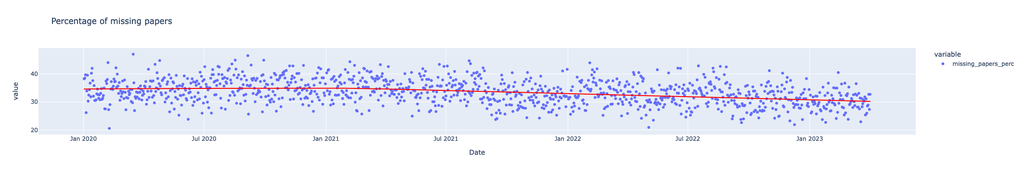

```python
px.scatter(df_train_soldout.groupby(feat_date)["missing_papers_perc"].mean(), trendline="lowess", trendline_color_override="red", title="Percentage of missing papers")
```

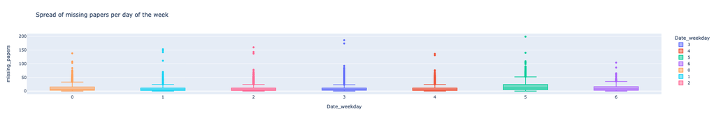

```python
px.box(df_train_soldout, x=f"{feat_date}_weekday", y="missing_papers" , color=f"{feat_date}_weekday", title="Spread of missing papers per day of the week")
```

The number of sold outs is greater on saturdays.

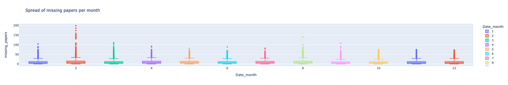

```python
px.box(df_train_soldout, x=f"{feat_date}_month", y="missing_papers" , color=f"{feat_date}_month", title="Spread of missing papers per month")
```

The number of soldouts in February is the highest one.

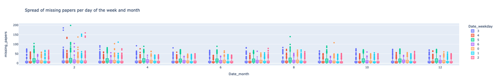

```python
px.box(df_train_soldout, x=f"{feat_date}_month", y="missing_papers" , color=f"{feat_date}_weekday", title="Spread of missing papers per day of the week and month")
```

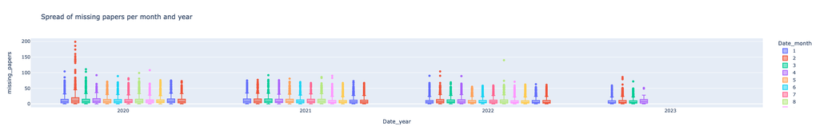

```python
px.box(df_train_soldout, x=f"{feat_date}_year", y="missing_papers" , color=f"{feat_date}_month", title="Spread of missing papers per month and year")
```

The number of sold outs during is important during February 2020. It can be explained by the fact that the number of sales is important in february 2020 due to covid.

One improvement could be to have the info of important events that can be predicted, like the elections, sports events or a period with an important event spreading on several days.

## 3.2.2 Unsold rates

```python
df_train_unsold = get_unsold_rows(df_train, pred_train, y_train.values)
df_train_unsold["remaining_papers"] = df_train_unsold['fourni'] - df_train_unsold['ventes']
df_train_unsold["remaining_papers_perc"] = df_train_unsold["remaining_papers"] / df_train_unsold['fourni'] * 100
df_train_unsold
```

|  | Date | Fourni | id | sma_1_ventes_lag14 | sma_2_ventes_lag14 | sma_3_ventes_lag14 | sma_4_ventes_lag14 | sma_5_ventes_lag14 | sma_6_ventes_lag14 | sma_7_ventes_lag14 | ... | Date_weekday | Date_weekend | lockdown | Description_ZoneA | Description_ZoneB | Description_ZoneC | ventes | fourni | remaining_papers | remaining_papers_perc |
| --- | --- | --- | --- | --- | --- | --- | --- | --- | --- | --- | --- | --- | --- | --- | --- | --- | --- | --- | --- | --- | --- |
| 63 | 2020-01-02 | 8.0 | 6199345349144345845 | NaN | NaN | NaN | NaN | NaN | NaN | NaN | ... | 3 | 0 | 0 | Vacances de Noël | Vacances de Noël | Vacances de Noël | 5.0 | 13.0 | 8.0 | 61.538462 |
| 72 | 2020-01-02 | 7.0 | -876129535061941331 | NaN | NaN | NaN | NaN | NaN | NaN | NaN | ... | 3 | 0 | 0 | Vacances de Noël | Vacances de Noël | Vacances de Noël | 2.0 | 10.0 | 8.0 | 80.000000 |
| 1 | 2020-01-02 | 8.0 | -8929187383922749181 | NaN | NaN | NaN | NaN | NaN | NaN | NaN | ... | 3 | 0 | 0 | Vacances de Noël | Vacances de Noël | Vacances de Noël | 3.0 | 11.0 | 8.0 | 72.727273 |
| 24 | 2020-01-02 | 2.0 | 8464427600310081793 | NaN | NaN | NaN | NaN | NaN | NaN | NaN | ... | 3 | 0 | 0 | Vacances de Noël | Vacances de Noël | Vacances de Noël | 2.0 | 14.0 | 12.0 | 85.714286 |
| 2 | 2020-01-02 | 14.0 | 5557283775796994165 | NaN | NaN | NaN | NaN | NaN | NaN | NaN | ... | 3 | 0 | 0 | Vacances de Noël | Vacances de Noël | Vacances de Noël | 8.0 | 12.0 | 4.0 | 33.333333 |
| ... | ... | ... | ... | ... | ... | ... | ... | ... | ... | ... | ... | ... | ... | ... | ... | ... | ... | ... | ... | ... | ... |
| 82382 | 2023-04-02 | 11.0 | -8793000144743990337 | 4.0 | 5.5 | 5.000000 | 4.25 | 4.0 | 4.166667 | 4.428571 | ... | 6 | 1 | 0 | None | None | None | 15.0 | 19.0 | 4.0 | 21.052632 |
| 82383 | 2023-04-02 | 20.0 | -6795017860123346820 | 15.0 | 13.5 | 12.333333 | 13.25 | 14.8 | 16.500000 | 16.000000 | ... | 6 | 1 | 0 | None | None | None | 1.0 | 16.0 | 15.0 | 93.750000 |
| 82387 | 2023-04-02 | 33.0 | -7764481442715308751 | 17.0 | 16.5 | 17.333333 | 17.00 | 19.2 | 20.833333 | 20.428571 | ... | 6 | 1 | 0 | None | None | None | 7.0 | 15.0 | 8.0 | 53.333333 |
| 82388 | 2023-04-02 | 20.0 | -7098573545404969117 | 18.0 | 16.0 | 13.333333 | 12.25 | 11.6 | 11.333333 | 11.714286 | ... | 6 | 1 | 0 | None | None | None | 6.0 | 17.0 | 11.0 | 64.705882 |
| 82389 | 2023-04-02 | 10.0 | 2942031581314612067 | 8.0 | 6.5 | 5.666667 | 4.75 | 4.6 | 4.666667 | 4.571429 | ... | 6 | 1 | 0 | None | None | None | 0.0 | 16.0 | 16.0 | 100.000000 |

60607 rows × 27 columns

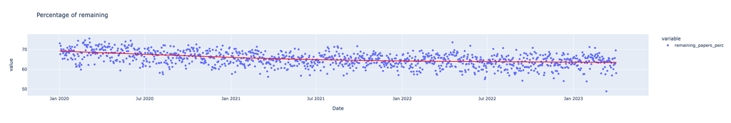

```python
px.scatter(df_train_unsold.groupby(feat_date)["remaining_papers_perc"].mean(), trendline="lowess", trendline_color_override="red", title="Percentage of remaining")
```

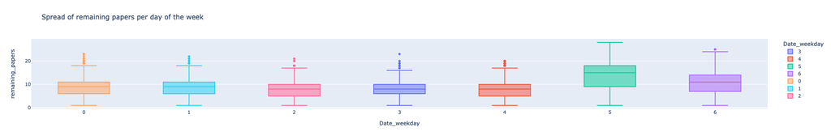

```python
px.box(df_train_unsold, x=f"{feat_date}_weekday", y="remaining_papers" , color=f"{feat_date}_weekday", title="Spread of remaining papers per day of the week")
```

Saturday is the day with the most remaining newspapers. It is also the day with the most newspapers sold so it explains the difficulty to give to predict the right amount of newspapers to deliver.

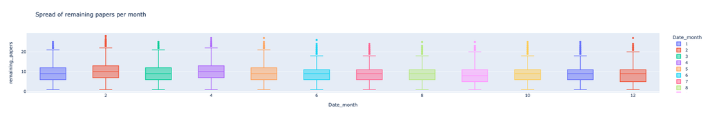

```python
px.box(df_train_unsold, x=f"{feat_date}_month", y="remaining_papers" , color=f"{feat_date}_month", title="Spread of remaining papers per month")
```

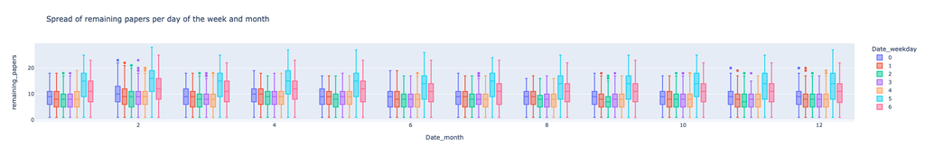

```python
px.box(
    df_train_unsold.sort_values(by=[f"{feat_date}_month", f"{feat_date}_weekday"]),
    x=f"{feat_date}_month", y="remaining_papers" , color=f"{feat_date}_weekday",
    title="Spread of remaining papers per day of the week and month")
```

The weekend is always the period with the most remaining papers

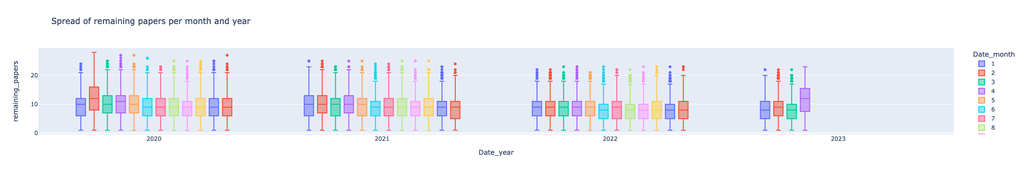

```python
px.box(df_train_unsold, x=f"{feat_date}_year", y="remaining_papers" , color=f"{feat_date}_month", title="Spread of remaining papers per month and year")
```